# Differential analysis with CATALYST

Helena L Crowell and Mark D Robinson

Institute for Molecular Life Sciences, University of Zurich, Switzerland  
SIB Swiss Institute of Bioinformatics, University of Zurich, Switzerland  
Department of Biosystems Science and Engineering ETH, ETH Zurich, Switzerland

helena.crowell@uzh.ch

29 April 2019

#### Package

CATALYST 1.7.8

# Contents

**Most of the pipeline and visualizations presented herein were adapted from Nowicka et al. (2017)’s *“CyTOF workflow: differential discovery in high-throughput high-dimensional cytometry datasets”*. For the complete workflow, go here.**

```r
# load required packages
suppressPackageStartupMessages({
    library(CATALYST)
    library(flowCore)
    library(diffcyt)
    library(SummarizedExperiment)
})
```

# 1 Example data

```r
# load example data
data(PBMC_fs, PBMC_panel, PBMC_md)
PBMC_fs
```

```
## A flowSet with 8 experiments.
##
##   column names:
##   CD3(110:114)Dd CD45(In115)Dd pNFkB(Nd142)Dd pp38(Nd144)Dd CD4(Nd145)Dd CD20(Sm147)Dd CD33(Nd148)Dd pStat5(Nd150)Dd CD123(Eu151)Dd pAkt(Sm152)Dd pStat1(Eu153)Dd pSHP2(Sm154)Dd pZap70(Gd156)Dd pStat3(Gd158)Dd CD14(Gd160)Dd pSlp76(Dy164)Dd pBtk(Er166)Dd pPlcg2(Er167)Dd pErk(Er168)Dd pLat(Er170)Dd …
```

```r
head(PBMC_panel)
```

```
## # A tibble: 6 x 3
##   fcs_colname    antigen marker_class
##   <chr>          <chr>   <chr>
## 1 CD3(110:114)Dd CD3     type
## 2 CD45(In115)Dd  CD45    type
## 3 pNFkB(Nd142)Dd pNFkB   state
## 4 pp38(Nd144)Dd  pp38    state
## 5 CD4(Nd145)Dd   CD4     type
## 6 CD20(Sm147)Dd  CD20    type
```

```r
head(PBMC_md)
```

```
##                 file_name sample_id condition patient_id
## 1 PBMC_patient1_BCRXL.fcs    BCRXL1     BCRXL   Patient1
## 2   PBMC_patient1_Ref.fcs      Ref1       Ref   Patient1
## 3 PBMC_patient2_BCRXL.fcs    BCRXL2     BCRXL   Patient2
## 4   PBMC_patient2_Ref.fcs      Ref2       Ref   Patient2
## 5 PBMC_patient3_BCRXL.fcs    BCRXL3     BCRXL   Patient3
## 6   PBMC_patient3_Ref.fcs      Ref3       Ref   Patient3
```

The code snippet below demonstrates how to construct a `flowSet` from a set of FCS files. However, we also give the option to directly specify the path to a set of FCS files (see next section).

```r
# download exemplary set of FCS files
url <- "http://imlspenticton.uzh.ch/robinson_lab/cytofWorkflow"
fcs_zip <- "PBMC8_fcs_files.zip"
download.file(paste0(url, "/", fcs_zip), destfile = fcs_zip, mode = "wb")
unzip(fcs_zip)

# read in FCS files as flowSet
fcs_files <- list.files(pattern = ".fcs$")
fs <- read.flowSet(fcs_files, transformation = FALSE, truncate_max_range = FALSE)
```

# 2 Data organization: The `daFrame` class

Data used and returned throughout differential analysis are held in objects of the `daFrame` class. Its constructor requires the following inputs:

- `x`: a `flowSet` holding the raw measurement data, or a character string that specifies a path to a set of FCS files.
- `panel`: a 2 column data.frame that contains for each marker of interest i) its column name in the raw input data, and ii) its targeted protein marker.
- `md`: a data.frame with columns describing the experimental design.

Optionally, `cols_to_use` will specify which columns (channels) to keep from the input data. Here, we keep all measurement parameters (default value `cols_to_use = NULL`).

```r
# construct daFrame
(daf <- daFrame(PBMC_fs, PBMC_panel, PBMC_md))
```

```
## class: daFrame
## dim: 5428 24
## metadata(2): experiment_info cofactor
## assays(1): exprs
## rownames: NULL
## rowData names(3): sample_id condition patient_id
## colnames(24): CD3 CD45 ... HLA_DR CD7
## colData names(3): channel_name marker_name marker_class
## reducedDimNames(0):
## spikeNames(0):
```

We provide flexibility in the way the panel and metadata table can be set up. Specifically, column names are allowed to differ from the example above, and multiple factors (patient ID, conditions, batch etc.) can be specified. Arguments `panel_cols` and `md_cols` should then be used to specify which columns hold the required information. An example is given below:

```r
# alter panel column names
panel2 <- PBMC_panel
colnames(panel2)[1:2] <- c("channel_name", "marker")

# alter metadata column names & add 2nd condition
md2 <- PBMC_md
colnames(md2) <- c("file", "sampleID", "cond1", "patientID")
md2$cond2 <- rep(c("A", "B"), 4)

# construct daFrame
daFrame(PBMC_fs, panel2, md2,
    panel_cols = list(channel = "channel_name", antigen = "marker"),
    md_cols = list(file = "file", id = "sampleID",
        factors = c("cond1", "cond2", "patientID")))
```

Note that, independent of the input panel and metadata tables, the constructor will fix the names of mandatory slots for latter data accession (`sample_id` in the `rowData`, `channel_name` and `marker_name` in the `colData`). The `md` table will be stored under `experiment_info` inside the `metadata`.

# 3 Diagnostic plots

## 3.1 `plotCounts`: Number of cells measured per sample

The number of cells measured per sample may be plotted with `plotCounts`, or directly accessed via `n_cells()`. This plot should be used as a guide together with other readouts to identify samples where not enough cells were assayed.

```r
n_cells(daf)
```

```
## BCRXL1   Ref1 BCRXL2   Ref2 BCRXL3   Ref3 BCRXL4   Ref4
##    528    881    665    438    563    660    934    759
```

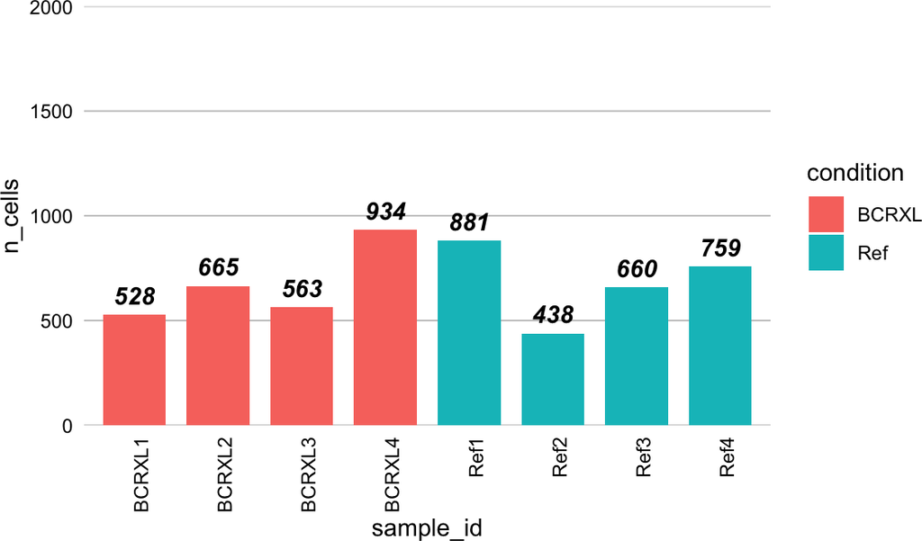

```r
plotCounts(daf, color_by = "condition")
```

## 3.2 `plotMDS`: Multi-dimensional scaling plot

A multi-dimensional scaling (MDS) plot on median expresion values may be rendered with `plotMDS`. Such a plot will give a sense of similarities between samples in an unsupervised way and of key difference in expression before conducting any formal testing. In our example, we can see a clear separation between reference (REF) and stimulation condition (BCRXL).

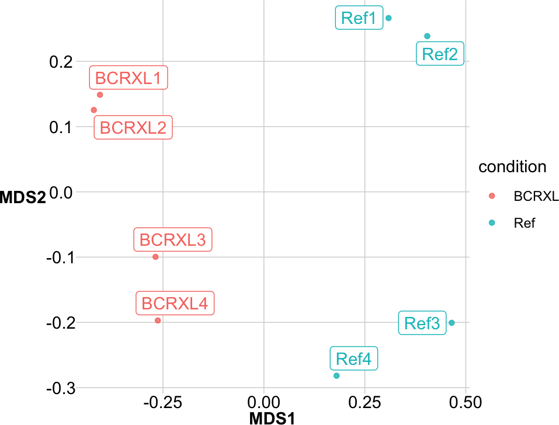

```r
plotMDS(daf, color_by = "condition")
```

## 3.3 `plotExprHeatmap`: Heatmap of (scaled) median marker expressions

`plotExprHeatmap` will show a heatmap on median marker intensities with hierarchically clustered rows (samples) and columns (markers). This plot should give an idea of which markers will drive sample clustering, and how similiar samples are in their expression profile. We specify `bin_anno = TRUE` to display expression values inside each bin, and `row_anno = TRUE` to include row annotations for each factor in `metadata(daf)`.

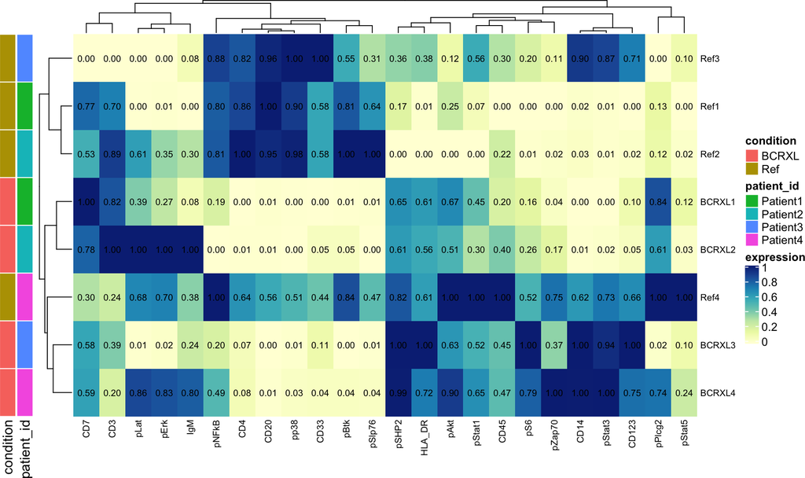

```r
plotExprHeatmap(daf, bin_anno = TRUE, row_anno = TRUE)
```

# 4 Clustering

## 4.1 `cluster`: *FlowSOM* clustering & *ConsensusClusterPlus* metaclustering

*CATALYST* provides a simple wrapper to perform high resolution `FlowSOM` clustering and lower resolution `ConsensusClusterPlus` metaclustering. By default, the data will be initially clustered into `xdim = 10` x `ydim = 10` = 100 groups. Secondly, the function will metacluster populations into 2 through `maxK` (default 20) clusters. To make analyses reproducible, the random seed may be set via `seed`. By default, if the `colData()$marker_class` column is specified, the set of markers with marker class “type” will be used for clustering. Alternatively, the markers that should be used for clustering can be specified with argument `cols_to_use`.

```r
# specify markers to use for clustering
lineage_markers <- c("CD3", "CD45", "CD4", "CD20",
    "CD33", "CD123", "CD14", "IgM", "HLA_DR", "CD7")
daf <- cluster(daf, cols_to_use = lineage_markers,
    xdim = 10, ydim = 10, maxK = 20, verbose = FALSE, seed = 1)
```

Let K = `xdim` x `ydim` be the number of *FlowSOM* clusters. `cluster` will add information to the following slots of the input `daFrame`:

- `rowData`:
  - `cluster_id`: cluster ID as inferred by *FlowSOM*. One of 1, …, K.
- `colData`:
  - `marker_class`: factor `"type"` or `"state"`. Specifyies whether a marker has been used for clustering or not, respectively.
- `metadata`:
  - `SOM_codes`: a table with dimensions K x (# type markers). Contains the SOM codes.
  - `cluster_codes`: a table with dimensions K x (`maxK` + 1). Contains the cluster codes for all metaclusterings.
  - `delta_area`: a `ggplot` object (see below for details).

## 4.2 Delta area plot

The delta area represents the amount of extra cluster stability gained when clustering into k groups as compared to k-1 groups. It can be expected that high stability of clusters can be reached when clustering into the number of groups that best fits the data. The “natural” number of clusters present in the data should thus corresponds to the value of k where there is no longer a considerable increase in stability (pleateau onset). For more details, the user can refer to the original description of the consensus clustering method (Monti et al. 2003).

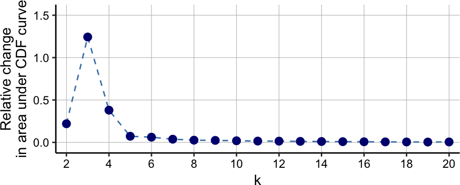

```r
# access & render delta area plot
metadata(daf)$delta_area
```

## 4.3 `plotMedExprs`: Median marker-expressions by cluster

A combined boxplot and jitter of median marker intensitied can be generated via `plotMedExprs`. In order to compare medians for each cluster, and potentially identify changes across conditions early on, we specify `facet = "cluster_id"`.

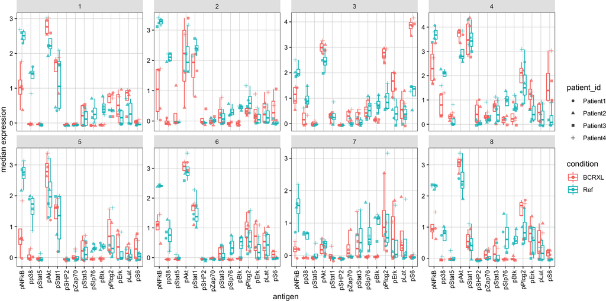

```r
p <- plotMedExprs(daf, k = "meta8", facet = "cluster_id",
  group_by = "condition", shape_by = "patient_id")
p$facet$params$ncol <- 4
p
```

Alternatively, we can facet the above plot by `antigen` in order to compare marker expressions calculated over all cells across conditions:

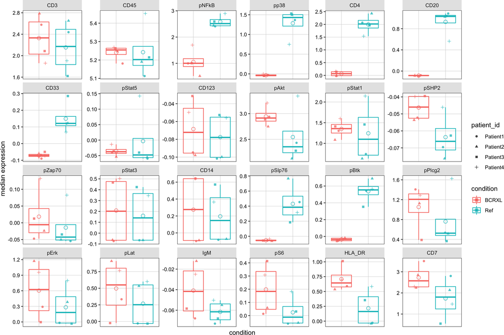

```r
p <- plotMedExprs(daf, facet = "antigen",
  group_by = "condition", shape_by = "patient_id")
p$facet$params$ncol <- 6
p
```

## 4.4 `plotClusterExprs`: Marker-densities by cluster

Distributions of marker intensities (arcsinh-transformed) across cell populations of interest can be plotted with `plotClusterExprs`. We specify `markers = "type"` (equivalent to `type_markers(daf)`), to include type-markers only. Here, blue densities are calculated over all cells and serve as a reference.

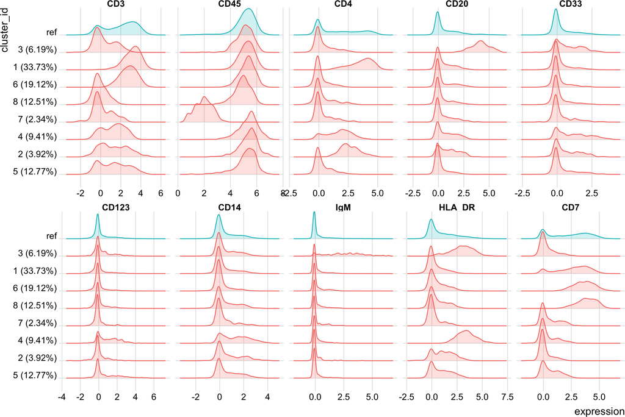

```r
plotClusterExprs(daf, k = "meta8", markers = "type")
```

## 4.5 `mergeClusters`: Manual cluster merging

Provided with a 2 column data.frame containing `old_cluster` and `new_cluster` IDs, `mergeClusters` allows for manual cluster merging of any clustering available within the input `daFrame` (i.e. the `xdim` x `ydim` *FlowSOM* clusters, and any of the 2-`maxK` *ConsensusClusterPlus* metaclusters). For latter accession (visualization, differential testing), the function will assign a unique ID (specified with `id`) to each merging, and add a column to the `cluster_codes` inside the `metadata` slot of the input `daFrame`.

```r
data(merging_table)
head(merging_table)
```

```
## # A tibble: 6 x 2
##   old_cluster new_cluster
##         <dbl> <chr>
## 1           1 B-cells IgM+
## 2           2 surface-
## 3           3 NK cells
## 4           4 CD8 T-cells
## 5           5 B-cells IgM-
## 6           6 monocytes
```

```r
daf <- mergeClusters(daf, k = "meta20", table = merging_table, id = "merging1")
head(cluster_codes(daf))
```

```
##   som100 meta2 meta3 meta4 meta5 meta6 meta7 meta8 meta9 meta10 meta11
## 1      1     1     1     1     1     1     1     1     1      1      1
## 2      2     1     1     1     1     1     1     1     1      1      1
## 3      3     1     1     1     1     1     1     1     1      2      2
## 4      4     1     1     1     1     1     1     1     1      2      2
## 5      5     1     1     1     1     1     1     1     1      2      2
## 6      6     1     2     2     2     2     2     2     2      3      3
##   meta12 meta13 meta14 meta15 meta16 meta17 meta18 meta19 meta20
## 1      1      1      1      1      1      1      1      1      1
## 2      1      1      1      1      1      1      1      1      1
## 3      2      2      2      2      2      2      2      2      2
## 4      2      2      2      2      2      2      2      2      2
## 5      2      2      2      2      2      2      2      2      2
## 6      3      3      3      3      3      3      3      3      3
##       merging1
## 1 B-cells IgM+
## 2 B-cells IgM+
## 3     surface-
## 4     surface-
## 5     surface-
## 6     NK cells
```

## 4.6 `plotClusterHeatmap`: Heatmap of (meta)clustering results

Clusterings and metaclusters maybe be viewing with the `plotClusterHeatmap`. In its 1st panel, the function will display median (arcsinh-transformed and *optionally* scaled) cell-type marker expressions (across all samples). Depending on argument `hm2`, the 2nd panel will vary as follows:

- `"abundances"`: cluster frequencies by sample;
- `"state_markers"`: median cell state marker expressions across clusters (analogous to the left-hand side heatmap);
- a character string/vector corresponding to one/multiple marker(s): median marker expressions by sample.

Argument `scale` (default `TRUE`) specifies whether scaled values should be plotted. These correspond to arcsinh-transformed expression values scaled between 0 and 1 using low (1%) and high (99%) percentiles as boundaries. Note that, in any case, hierarchical clustering is performed on the unscaled data.  
While it is only used here for visualization, this additional transformation of the arcsinh-transformed data can sometimes give a better representation of relative differences in marker expression between cell populations.

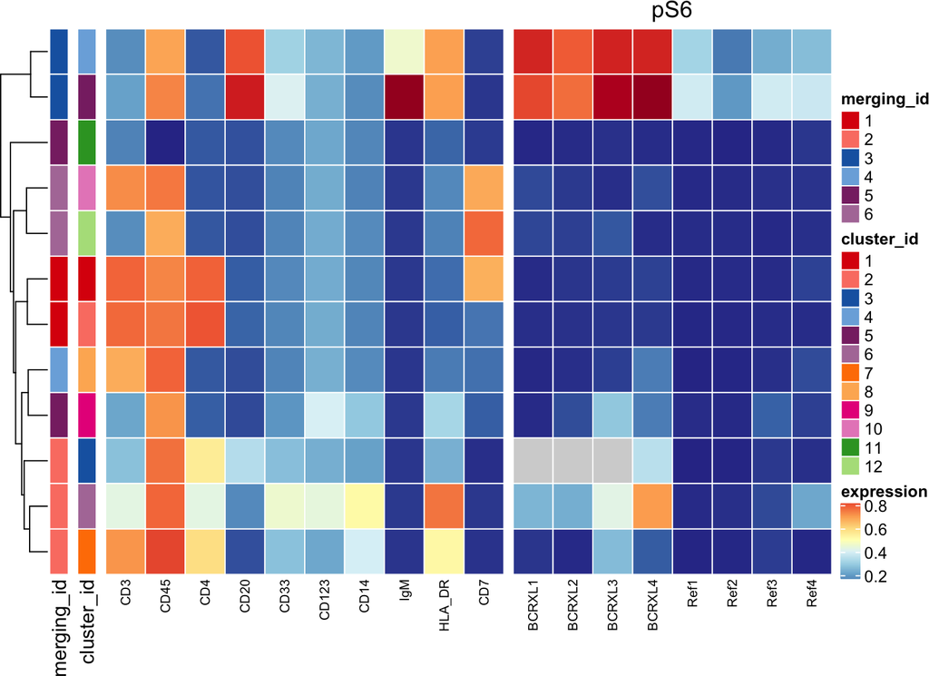

```r
# median pS6 expression by sample as 2nd heatmap
plotClusterHeatmap(daf, hm2 = "pS6", k = "meta12", m = "meta6")
```

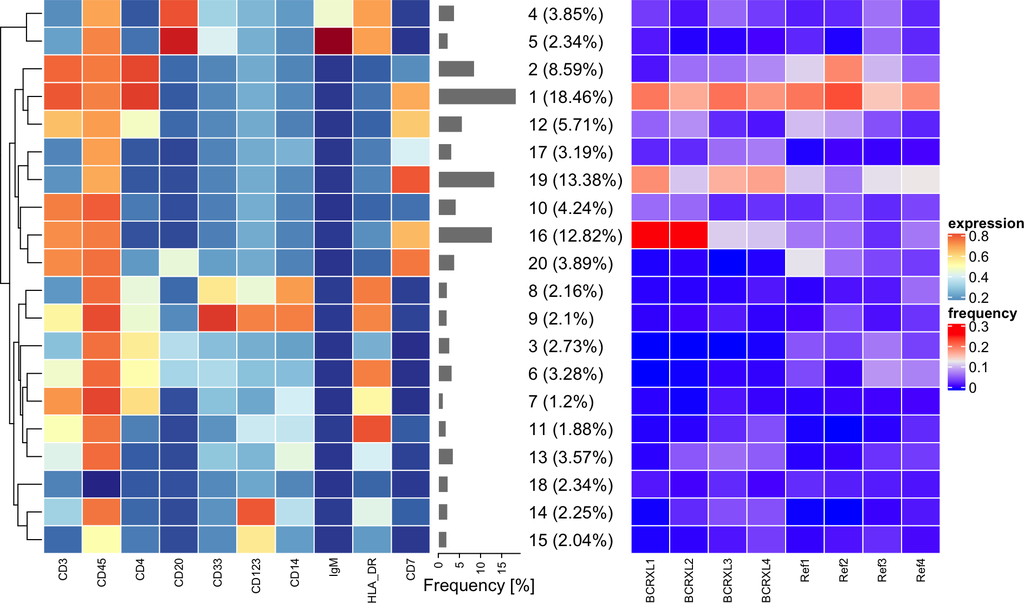

```r
# population frequencies by sample as 2nd heatmap
plotClusterHeatmap(daf, hm2 = "abundances",
    draw_freqs = TRUE, cluster_anno = FALSE)
```

## 4.7 `plotAbundances`: Relative population abundances

Relative population abundances for any clustering of interest can be plotted with `plotAbundances`. Argument `by` will specify whether to plot proportions for each sample or cluster.  
If `by = "sample_id"`, the function displays each sample’s cell type composition, and the size of a given stripe reflects the proportion of the corresponding cell type the given sample. Argument `group` then specifies the facetting. If `by = "cluster_id"`, argument `group` then specifies the grouping and color coding.

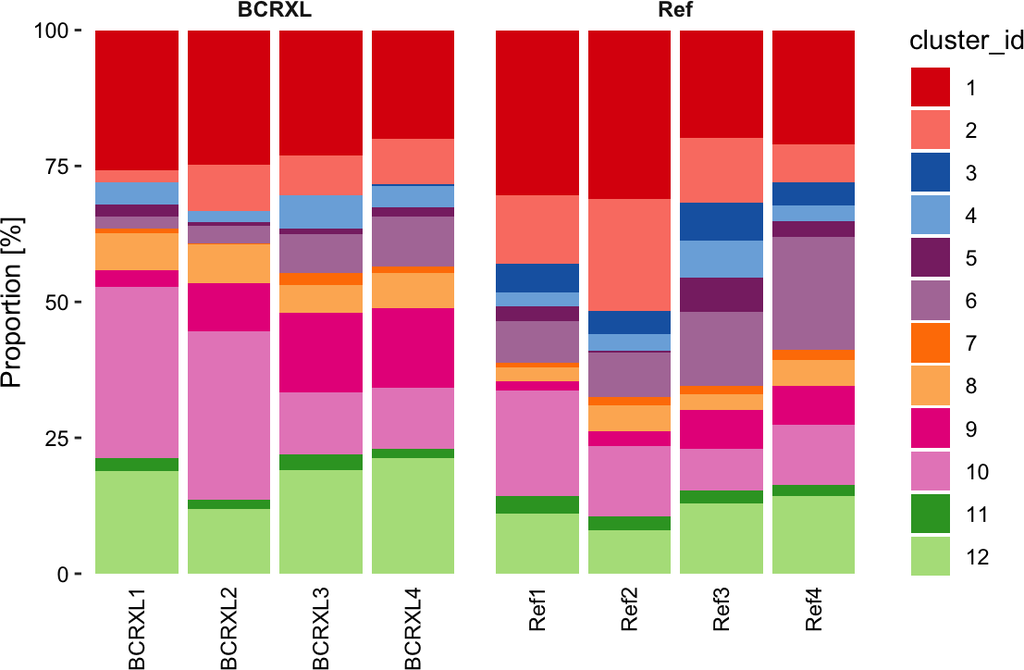

```r
plotAbundances(daf, k = "meta12", by = "sample_id", group = "condition")
```

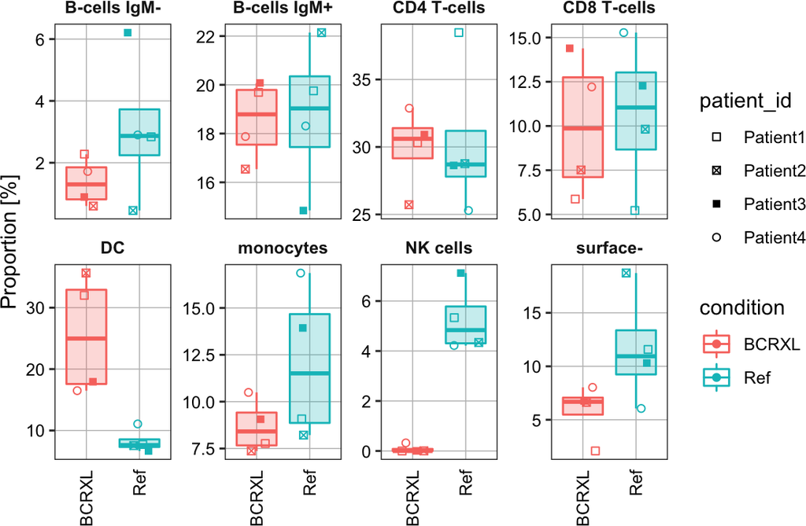

```r
plotAbundances(daf, k = "merging1", by = "cluster_id", group = "condition")
```

# 5 Dimensionality reduction with `runDR`

The set of dimension reduction (DR) methods available from the *scater* can be applied using `runDR`. To make results reproducible, the random seed should be set via `set.seed` *prior* to running `runDR`. The subset of markers to use is specified via `cols_to_use`, and the cells to use with argument `rows_to_use`. When `rows_to_use` is a single numeric value N, `runDR` will draw a random subset of N cells per sample. `CATALYST` allows DRs to use different sets of cells. In the example below, we can run a PCA on the full dataset, but more time-consuming methods, e.g., t-SNE or UMAP, on only a subset of cells.

```r
# run PCA on all cells
set.seed(1)
daf <- runDR(daf, "PCA")

# run UMAP on 200 cells per sample
set.seed(2)
daf <- runDR(daf, "UMAP", rows_to_use = 200)
```

As in a regular *SingleCellExperiment*, DRs available within the `daFrame` can be viewed via `reducedDimNames` and accessed with `reducedDim(s)`.

```r
# view & access DRs
reducedDimNames(daf)
```

```
## [1] "PCA"  "UMAP"
```

```r
reducedDims(daf)
```

```
## List of length 2
## names(2): PCA UMAP
```

```r
head(reducedDim(daf, "PCA"))
```

```
##            PCA1       PCA2
## [1,] -0.8842050  0.1580524
## [2,] -0.2409804 -1.3562566
## [3,]  3.5161452 -0.6373593
## [4,] -0.5935625 -1.0838852
## [5,] -1.3820122 -0.6742902
## [6,]  1.4908868  0.7474590
```

```r
# all cells
nrow(reducedDim(daf, "PCA")) == nrow(daf)
```

```
## [1] TRUE
```

```r
# 200 per sample
nrow(reducedDim(daf, "UMAP")) == 200 * nlevels(sample_ids(daf))
```

```
## [1] TRUE
```

## 5.1 `plotDR`: Visualizing reduced dimensions

`plotDR` is a flexbile wrapper to plot reduced dimensions stored within the `reducedDims` slot of a `daFrame`. The coloring of cell projections is specified with argument `color_by`, and may correspond to a marker, clustering, or any factor available in the `daFrame`’s `rowData`. In order to facilitate comparing reduced dimensions across experimental groups or samples, embeddings can be split via `facet`.

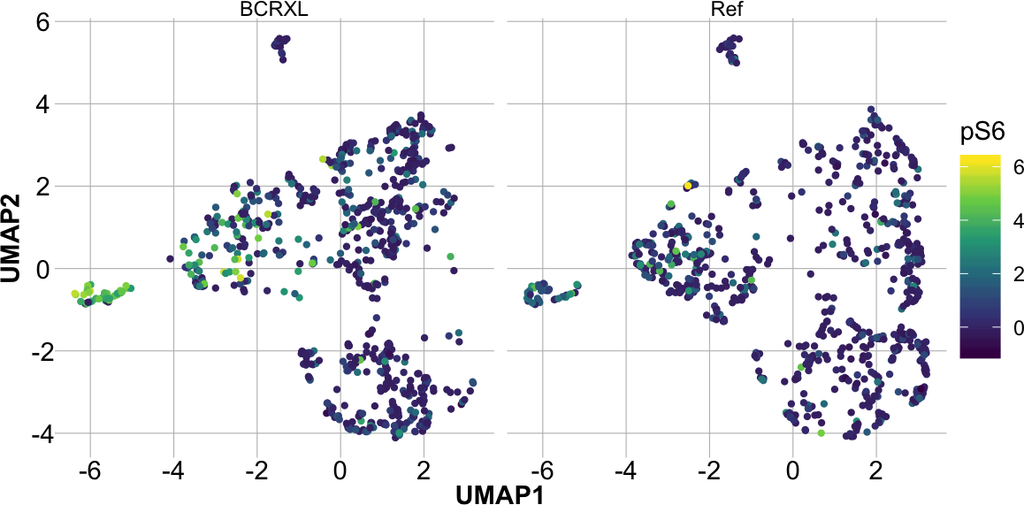

```r
# color by marker expression & split by condition
plotDR(daf, "UMAP", color_by = "pS6", facet = "condition")
```

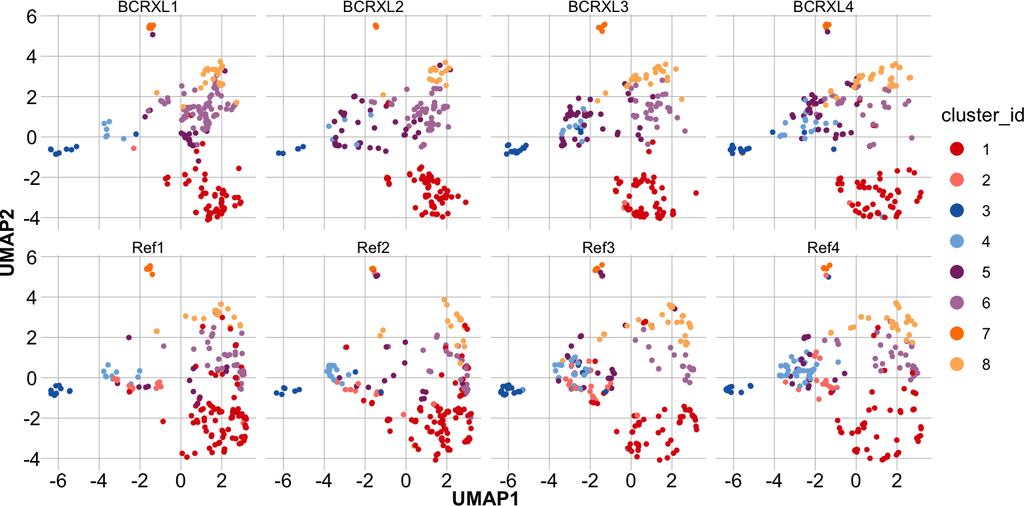

```r
# color by 8 metaclusters & split by sample ID
plotDR(daf, "UMAP", color_by = "meta8", facet = "sample_id")
```

# 6 Differental testing with *diffcyt*

*CATALYST* has been designed to be compatible with the *diffcyt* package (Weber 2018), which implements statistical methods for differential discovery in high-dimensional cytometry (including flow cytometry, mass cytometry or CyTOF, and oligonucleotide-tagged cytometry) using high-resolution clustering and moderated tests. The input to the *diffcyt* pipeline can either be raw data, or a `daFrame` object. We give an exmaple of the latter below.  
Please refer to the *diffcyt* [vignette](https://bioconductor.org/packages/3.7/bioc/vignettes/diffcyt/inst/doc/diffcyt_workflow.html) and R documentation (`??diffcyt`) for more detailed information.

```r
# create design & constrast matrix
formula <- createFormula(
    experiment_info = PBMC_md,
    cols_fixed = "condition",
    cols_random = "patient_id")
contrast <- createContrast(c(0, 1))
# test for
# - differential abundance (DA) of clusters
# - differential states (DS) within clusters
res_DA <- diffcyt(daf, contrast = contrast, formula = formula,
    analysis_type = "DA", method_DA = "diffcyt-DA-GLMM", clustering_to_use = "meta10")
res_DS <- diffcyt(daf, contrast = contrast, formula = formula,
    analysis_type = "DS", method_DS = "diffcyt-DS-LMM", clustering_to_use = "meta10")
```

## 6.1 `plotDiffHeatmap`: Heatmap of differential testing results

Differential testing results returned by *diffcyt* can be displayed with the `plotDiffHeatmap` function.

For differential abundance (DA) tests, `plotDiffHeatmap` will display

- median (arcsinh-transformed) cell-type marker expressions (across all samples), and
- relative cluster abundances by samples

For differential state (DS) tests, `plotDiffHeatmap` will display

- median (arcsinh-transformed) cell-type marker expressions (across all samples)
- median (arcsinh-transformed) cell-state marker expressions by sample

Clusters (DA) and cluster-marker combinations (DS), respectively, will be marked as *significant* if their adjusted p-value falls below the threshold value specified with `th` (default 0.1), and will be ordered by significance if `order = TRUE` (the default). The number of top findings to display can be specified with `top_n` (default 20). When `normalize = TRUE`, the right-hand side heatmap will display Z-score normalized values. For DA, cluster frequencies will be arcsine-square-root scaled prior to normalization.

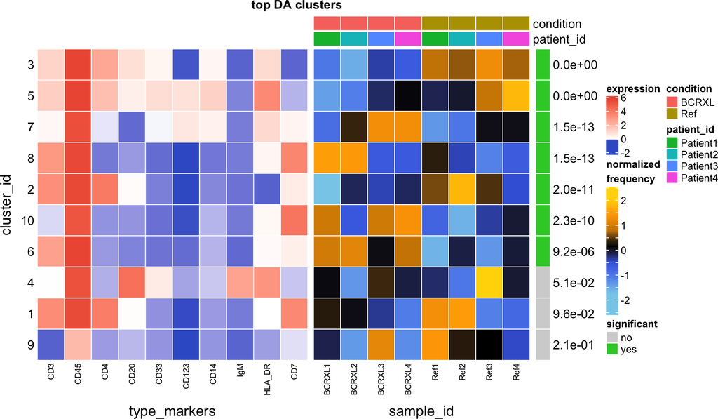

```r
plotDiffHeatmap(daf, res_DA, all = TRUE, th = 0.05)
```

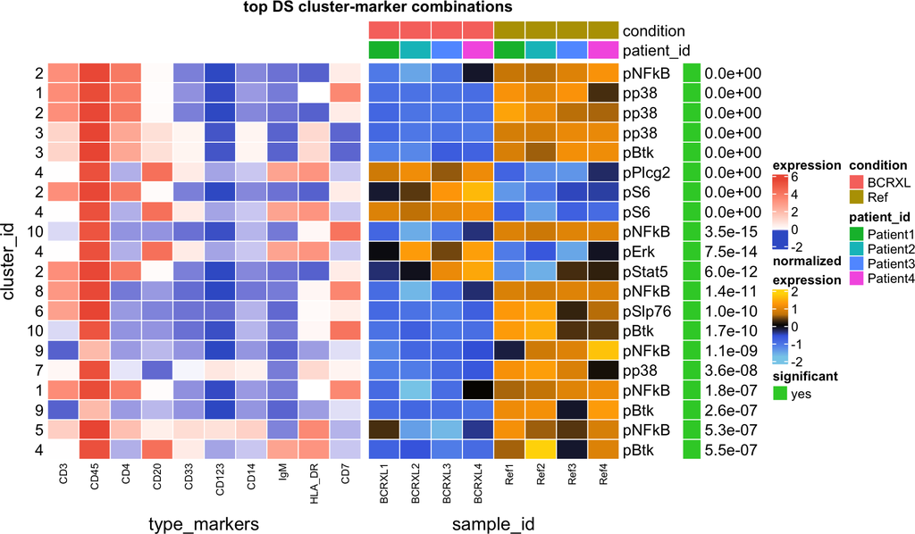

```r
plotDiffHeatmap(daf, res_DS, top_n = 20)
```

# References

Bodenmiller, Bernd, Eli R Zunder, Rachel Finck, Tiffany J Chen, Erica S Savig, Robert V Bruggner, Erin F Simonds, et al. 2012. “Multiplexed Mass Cytometry Profiling of Cellular States Perturbed by Small-Molecule Regulators.” *Nature Biotechnology* 30 (9): 858–67. https://doi.org/10.1038/nbt.2317.

Bruggner, Robert V, Bernd Bodenmiller, David L Dill, Robert J Tibshirani, and Garry P Nolan. 2014. “Automated Identification of Stratifying Signatures in Cellular Subpopulations.” *Proceedings of the National Academy of Sciences of the United States of America* 111 (26): E2770–E2777. https://doi.org/10.1073/pnas.1408792111.

Monti, Stefano, Pablo Tamayo, Jill Mesirov, and Todd Golub. 2003. “Consensus Clustering: A Resampling-Based Method for Class Discovery and Visualization of Gene Expression Microarray Data.” *Machine Learning* 52 (1): 91–118. https://doi.org/10.1023/A:1023949509487.

Nowicka, M, C Krieg, LM Weber, FJ Hartmann, S Guglietta, B Becher, MP Levesque, and MD Robinson. 2017. “CyTOF Workflow: Differential Discovery in High-Throughput High-Dimensional Cytometry Datasets [Version 2; Referees: 2 Approved].” *F1000Research* 6 (748). https://doi.org/10.12688/f1000research.11622.2.

Weber, LM. 2018. “Diffcyt: Differential Discovery in High-Dimensional Cytometry via High-Resolution Clustering.” *R Package Version 1.0.0*. https://github.com/lmweber/diffcyt.